# WQP Data Harmonization

TADA Team

2023-02-28

## Overview

This vignette will walk through how to discover, wrangle, and harmonize [Water Quality Portal (WQP)](https://www.waterqualitydata.us/) data from multiple organizations.

## Install and load packages

To install TADA, currently you need to install from GitHub using remotes (shown) or devtools. dataRetrieval will be downloaded from CRAN, but the development version can be downloaded directly from GitHub (un-comment).

The following code will also install any packages you do not have, and load all packages required to run this vignette into your R session.

```r
list.of.packages <- c("plyr", "data.table", "dplyr", "magrittr", "stringr", "maps","utils", "RColorBrewer", "stats", "lubridate", "remotes", "dataRetrieval", "ggplot2")

new.packages <- list.of.packages[!(list.of.packages %in% installed.packages()[,"Package"])]

if(length(new.packages)) install.packages(new.packages, repos = "https://cloud.r-project.org/")
```

If you have any issues loading the remotes library using the code above, uncomment the line below to install the “remotes” package specifying the repo. You must load the remotes library before installing TADA and other packages from GitHub

```r
# install.packages("remotes", repos = "http://cran.us.r-project.org")
library(remotes)
```

Uncomment the lines below to install latest version of dataRetrieval and ggplot2 from GitHub.

```r
# remotes::install_github("USGS-R/dataRetrieval", dependencies=TRUE)

# remotes::install_github("hadley/ggplot2", dependencies=TRUE)

# remotes::install_github("USEPA/TADA", dependencies=TRUE)
remotes::install_github("USEPA/TADA", dependencies=TRUE, ref="name_clean_eh") # EDH temporarily switched source so that this will build with new functions/names
# if you experience any issues installing TADA, try uncommenting and running the line below before the install
# options(download.file.method = "wininet")
```

Load the required libraries to run this vignette into your R session

```r
# libraries loaded from CRAN
library(plyr)
library(data.table)
library(dplyr)
library(magrittr)
library(stringr)
library(utils)
library(RColorBrewer)
library(stats)
library(rlang)
library(lubridate)
library(ggplot2)
library(maps)
library(dataRetrieval)
library(TADA)
```

## Retrieve WQP data

WQP data is retrieved and processed for compatibility with TADA. This function, **TADAdataRetrieval**, builds on the USGS dataRetrieval package functions. It joins three WQP profiles (i.e., the station, narrow, and phys/chem), changes all data in the Characteristic, Speciation, Fraction, and Unit fields to uppercase, removes true duplicates, removes data for all non-water media types, and cleans up results with special characters.

This function uses the same inputs as the dataRetrieval `readWQPdata` function. `readWQPdata` does not restrict the characteristics pulled from [Water Quality Portal (WQP)](https://www.waterqualitydata.us/). You may specify the desired characteristics by using, for instance: characteristicName = “pH”.

Data retrieval filters include:

- statecode (review list of possible state and territory [abbreviations](https://www2.census.gov/geo/docs/reference/state.txt))
- endDate
- startDate
- countycode
- siteid
- siteType
- characteristicName
- sampleMedia
- project
- organization

Please be aware that this TADAdataRetrieval function automatically runs the TADA **autoclean** and **ConvertSpecialChars** functions as well, which are both required for subsequent functions within the TADA R package to run. As a general rule, TADA functions do not change any contents in the WQP-served columns (enter *?ConvertSpecialChars* and *?autoclean* into the console for more details). Instead, they add new columns with the prefix “TADA.” The following columns are numeric versions of their WQP origins:

```
-   TADA.ResultMeasureValue

-   TADA.DetectionQuantitationLimitMeasure.MeasureValue

-   TADA.LatitudeMeasure

-   TADA.LongitudeMeasure
```

These functions also add the columns TADA.ResultMeasureValueDataTypes.Flag and TADA.DetectionQuantitationLimitMeasure.MeasureValueDataTypes.Flag, which provide information about the result values that is needed to address censored data later on (i.e., nondetections). Specifically, these new columns flag if special characters are included in result values, and specifies what the special characters are.

Downloads using TADAdataRetrieval will have the same columns each time, but be aware that data are uploaded to the Water Quality Portal by individual organizations, which may or may not follow the same conventions. Data and metadata quality are not guaranteed! Make sure to carefully explore any data and make conservative quality assurance decisions where information is limited.

Tips:

1. All the query filters for the WQP work as an AND but within the fields there are ORs. For example:
   - Characteristics: If you choose pH & DO - it’s an OR. This means you will retrieve both pH OR DO data if available.
   - States: Similarly, if you choose VA and IL, it’s an OR. This means you will retrieve both VA OR IL data if available.
   - Combinations of fields are ANDs, such as State/VA AND Characteristic/DO”. This means you will receive all DO data available in VA.
   - “Characteristic” and “Characteristic Type” also work as an AND. This means that the Characteristic must fall within the CharacteristicGroup if both filters are being used, if not you will get an error.
2. The “siteid” is a general term WQP uses to describe both Site IDs from USGS databases and Monitoring Location Identifiers (from the Water Quality Portal). Each monitoring location in the Water Quality Portal (WQP) has a unique Monitoring Location Identifier, regardless of the database from which it derives. The Monitoring Location Identifier from the WQP is the concatenated Organization Identifier plus the Site ID number. Site IDs that only include a number are only unique identifiers for monitoring locations within USGS NWIS or EPA’s WQX databases separately.

Additional resources:

- Review function documentation by entering the following code into the console: ?TADAdataRetrieval
- [Introduction to the dataRetrieval package](https://CRAN.R-project.org/package=dataRetrieval)
- [General Data Import from Water Quality Portal](https://rdrr.io/cran/dataRetrieval/man/readWQPdata.html)
- [Water Quality Portal Web Services Guide](https://www.waterqualitydata.us/webservices_documentation/)
- [dataRetrieval Tutorial](https://owi.usgs.gov/R/dataRetrieval.html)

## dataRetrieval

Uncomment below if you would like to review differences between the profiles you would get using readWQPdata vs. TADAdataRetrieval. The profiles are different because TADAdataRetrieval automatically joins in data from multiple WQP profiles, and does some additional data cleaning as part of the data retrieval process.

```r
# dataRetrieval1 <- dataRetrieval::readWQPdata(statecode = "AK", characteristicName = c("Fecal Coliform", "Escherichia coli", "Enterococcus"), startDate = "2018-05-01", ignore_attributes = TRUE)

# another example
# dataRetrieval2 <- dataRetrieval::readWQPdata(statecode = "UT", characteristicName = c("Ammonia", "Nitrate", "Nitrogen"), startDate = "2021-01-01", ignore_attributes = TRUE)
```

Use the code below to download data from the WQP using TADAdataRetrieval. Edit the code chuck below to define your own WQP query inputs.

```r
# here is an example for Utah
# TADAProfile1 <- TADAdataRetrieval(statecode = "UT", characteristicName = c("Ammonia", "Nitrate", "Nitrogen"), startDate = "2020-10-01")

# example for Alaska
# TADAProfile2 <- TADAdataRetrieval(ProjectIdentifier = "Anchorage Bacteria 20-21")

# another example query for Alaska. We will move forward with this example in the remainder of the vignette
TADAProfile <- TADAdataRetrieval(statecode = "AK", characteristicName = c("Fecal Coliform", "Escherichia coli", "Enterococcus", "Ammonia", "Nitrate", "Nitrogen"), startDate = "2018-05-01")
```

Option 2: Alternatively, you can use the data.table::fread function to read in a web service call for any WQP profile (un-comment).

```r
# New_Draft_fullphyschem <- data.table::fread("https://www.waterqualitydata.us/data/Result/search?countrycode=US&statecode=US%3A49&siteid=UTAHDWQ_WQX-4925610&startDateLo=01-01-2015&startDateHi=12-31-2016&mimeType=csv&zip=no&sorted=yes&dataProfile=fullPhysChem&providers=NWIS&providers=STEWARDS&providers=STORET")
```

**Extra tip:** Note that the web service call built using the Water Quality Portal uses the inputs startDateLo and startDateHi rather than startDate and endDate, and dates are in the format MM-DD-YYYY rather than the TADAdataRetrieval and dataRetrieval format of YYYY-MM-DD. The functions use the latter format rather than the web service call date format because YYYY-MM-DD is a more easily utilized format in the R coding environment. However, users of USGS’s dataRetrieval may use the date format MM-DD-YYYY *only if* they specify with “startDateLo” and “startDateHi” inputs. For coding consistency, it is recommended users stick with YYYY-MM-DD.

Option 3: If you need to download a large amount of data from across a large area, and the TADAdataRetrieval function is not working due to WQP timeout issues, then the **TADABigdataRetrieval** function may work better.

This function does multiple synchronous data calls to the WQP (waterqualitydata.us). It uses the WQP summary service to limit the amount downloaded to only relevant data, and pulls back data from 100 stations at a time and then joins the data back together and produces a single TADA compatible dataframe as the output. For large dataframes, that can save a lot of time and ultimately reduce the complexity of subsequent data processing. Using this function, you will be able to download all data available from all sites in the contiguous United States that is available for the time period, characteristicName, statecode, and siteType requested.

See ?TADABigdataRetrieval for more details. WARNING, this can take multiple HOURS to run. The total run time depends on your query inputs.

```r
# WARNING, this can take multiple HOURS to run
# StreamTemp <- TADABigdataRetrieval(startDate = "2000-01-01",
#                                     endDate = "2022-12-31",
#                                     characteristicName = "Temperature, water",
#                                     statecode = c("AK","AL"))
#
# WaterTemp <- TADABigdataRetrieval(characteristicName = "Temperature, water")
#
# Phosphorus <- TADABigdataRetrieval(characteristicName = "Phosphorus")
#
# CT <- TADABigdataRetrieval(statecode = "CT")
```

Review all column names in the TADA Profile. Remove results that are not water samples or measurements (TADA is recommended for use with water data only).

```r
colnames(TADAProfile)
```

```
#>   [1] "OrganizationIdentifier"
#>   [2] "OrganizationFormalName"
#>   [3] "ActivityIdentifier"
#>   [4] "ActivityTypeCode"
#>   [5] "ActivityMediaName"
#>   [6] "ActivityMediaSubdivisionName"
#>   [7] "ActivityStartDate"
#>   [8] "ActivityStartTime.Time"
#>   [9] "ActivityStartTime.TimeZoneCode"
#>  [10] "ActivityEndDate"
#>  [11] "ActivityEndTime.Time"
#>  [12] "ActivityEndTime.TimeZoneCode"
#>  [13] "ActivityRelativeDepthName"
#>  [14] "ActivityDepthHeightMeasure.MeasureValue"
#>  [15] "ActivityDepthHeightMeasure.MeasureUnitCode"
```

[output cut: 121 more lines]

```r
TADAProfile_CharSummary <- SummarizeColumn(TADAProfile,"TADA.CharacteristicName")
TADAProfile_CharSummary
```

```
#> # A tibble: 6 × 3
#>   TADA.CharacteristicName n_sites n_records
#>   <chr>                     <int>     <int>
#> 1 AMMONIA                      38        46
#> 2 ENTEROCOCCUS                179      2761
#> 3 ESCHERICHIA COLI             34       286
#> 4 FECAL COLIFORM              234      3271
#> 5 NITRATE                      48       516
#> 6 NITROGEN                     54       291
```

```r
# Remove data for non-water media types
TADAProfile <- dplyr::filter(TADAProfile, TADA.ActivityMediaName == "WATER")
```

## Invalid coordinates

Review station locations

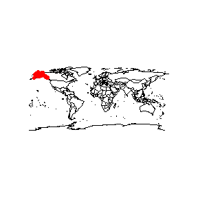

```r
#create a map of the world
maps::map()

# draw the sites included in your TADAProfile onto the map
points(TADAProfile$TADA.LongitudeMeasure, TADAProfile$TADA.LatitudeMeasure, col="red", pch=20)
```

The TADA **InvalidCoordinates** function identifies and flags potentially invalid coordinate data. While its functionality is showcased here, it is always important to review any invalid outputs before cleaning to reduce the risk of leaving out usable data/sites.

Allowable values for clean_outsideUSA are “no”, “remove”, or “change sign”. The default is “no” which flags latitude and longitude coordinates outside the USA. Assigning clean_ousideUSA = “remove” will remove rows of data with coordinates outside the USA. And assigning clean_outsideUSA = “change sign” will flip the sign of latitude or longitude coordinates flagged as outside the USA. The “change sign” option should only be used when it is known that coordinates were entered with the wrong sign in WQX; additionally, the data owner should fix these incorrect coordinates in the raw data through the WQX - for assistance email the WQX help desk: WQX@epa.gov

Allowable values for clean_imprecise are TRUE or FALSE. The default is FALSE which flags rows of data with invalid or imprecise coordinates without removing them. Assigning clean_imprecise = TRUE will remove rows of data with invalid or imprecise coordinates.

Allowable values for errorsonly are TRUE or FALSE. The default is FALSE which keeps all rows of data regardless of flag status. Assigning errorsonly = TRUE filters the dataframe to show only rows of data which are flagged.

When clean_outsideUSA = “no” and/or clean_imprecise = FALSE, a column will be appended titled “TADA.InvalidCoordinates.Flag” with the following flags (if relevant to dataframe):

- If the latitude is less than zero, the row will be flagged with “LAT_OutsideUSA”. (Exception for American Samoa)
- If the longitude is greater than zero AND less than 145, the row will be flagged as “LONG_OutsideUSA”. (Exceptions for Guam and the Northern Mariana Islands)
- If the latitude or longitude contains the string, “999”, the row will be flagged as invalid.
- Finally, precision can be measured by the number of decimal places in the latitude and longitude provided. If either does not have any numbers to the right of the decimal point, the row will be flagged as “Imprecise”.

```r
InvalidCoordinateFlags <- InvalidCoordinates(TADAProfile, clean_outsideUSA = "no", clean_imprecise = FALSE, errorsonly = TRUE)

# review unique flags in InvalidCoordinateFlags
unique(InvalidCoordinateFlags$TADA.InvalidCoordinates.Flag)
```

```
#> [1] "Imprecise_lessthan3decimaldigits" "Imprecise_Longincludes999"
```

```r
# review unique MonitoringLocationIdentifiers in your flag dataframe
unique(InvalidCoordinateFlags$MonitoringLocationIdentifier)
```

```
#> [1] "USGS-695924143420301"    "AKDECWQ-AnchBact20-Che3"
#> [3] "AKDECWQ-WHADA-Che3"
```

```r
Unique_InvalidCoordinateFlags <- InvalidCoordinateFlags %>%
  dplyr::select('MonitoringLocationIdentifier','MonitoringLocationName', 'TADA.InvalidCoordinates.Flag',
         'OrganizationIdentifier', 'TADA.LongitudeMeasure', 'TADA.LatitudeMeasure', 'MonitoringLocationTypeName',
         'CountryCode', 'StateCode', 'CountyCode', 'HUCEightDigitCode', 'MonitoringLocationDescriptionText',
         'ProjectName', 'ProjectIdentifier', 'OrganizationFormalName') %>%
  dplyr::distinct()

# remove all data for sites with invalid or imprecise coordinates. Change function inputs to keep this data, but be aware it may impact your mapping.
TADAProfileClean1 <- InvalidCoordinates(TADAProfile, clean_outsideUSA = "remove", clean_imprecise = TRUE, errorsonly = FALSE)
```

```
#> [1] "All invalid coordinates were removed or your dataframe does not contain monitoring stations with invalid coordinates"
```

## Depth unit conversions

The **ConvertDepthUnits** function converts depth units to a consistent unit. Depth values and units are most commonly associated with lake data, and are populated in the *ActivityDepthHeightMeasure*, *ActivityTopDepthHeightMeasure*, *ActivityBottomDepthHeightMeasure*, and *ResultDepthHeightMeasure* Result Value/Unit columns.

This function first checks the dataframe for depth profile data. Where depth profile columns are populated, the function appends ‘Conversion Factor’ columns and populates those columns based on the original unit and the target unit, which is defined in the ‘unit’ argument. A ‘Depth Target Unit’ column is also appended, indicating the unit all selected depth data is converted to. When transform = FALSE, the output includes all ‘Conversion Factor’ columns and the ‘Depth Target Unit’ column. When transform = TRUE, the output includes converted depth data and the ‘Depth Target Unit’ column, which acts as a flag indicating which rows have been converted. Default is transform = TRUE.

The depth profile function can harmonize the depth units across all the following fields (or only a specific one): “ActivityDepthHeightMeasure”, “ActivityTopDepthHeightMeasure”, “ActivityBottomDepthHeightMeasure”, “ResultDepthHeightMeasure”). It creates new result value/unit columns with the prefix “TADA.” to all converted columns. The default is to check all four Depth Height columns.

Allowable values for ‘unit’ are either ‘m’ (meter), ‘ft’ (feet), or ‘in’ (inch). ‘unit’ accepts only one allowable value as an input. Default is unit = “m”.

See additional function documentation for additional function options by entering the following code in the console: ?ConvertDepthUnits

```r
#converts all depth profile data to meters
TADAProfileClean2 <- ConvertDepthUnits(TADAProfileClean1, unit = "m", transform = TRUE)
```

## Result unit conversions

The **ConvertResultUnits** function converts all results to WQX target units. WQX target units are pulled from the MeasureUnit domain table:

- https://cdx.epa.gov/wqx/download/DomainValues/MeasureUnit.CSV

See additional function documentation for additional function options by entering the following code in the console: ?ConvertResultUnits

```r
#Converts all results to WQX target units
TADAProfileClean3 <- ConvertResultUnits(TADAProfileClean2, transform = TRUE)
```

## Statistically aggregated data

The **AggregatedContinuousData** function checks for and removes statistically aggregated high frequency (i.e., continuous) data, if present.

The Water Quality Portal (WQP) is not currently designed to store high-frequency sensor data (more than 1 value per day). However, sometimes data providers choose to aggregate their continuous data to a daily avg, max, or min value, and then submit that aggregated data to the WQP through WQX. Alternatively, some organizations aggregate their high frequency data (15 min or 1 hour data) to 2 or 4 hour interval averages, and they also submit that data to the WQP through WQX. This type of high frequency data may (or may not) be suitable for integration with discrete water quality data for assessments. Therefore, this function uses metadata submitted by data providers to flag rows with aggregated continuous data. This is done by flagging results where the ResultDetectionConditionText = “Reported in Raw Data (attached)”.

- When clean = FALSE, a column titled “TADA.AggregatedContinuousData” is added to the dataframe to indicate if the row includes aggregated continuous data, “Y”, or not, “N”.
- When clean = TRUE, rows with aggregated continuous data are removed from the dataframe and no column will be appended. The default is clean = TRUE.

An additional input called errorsonly will allow the user to filter data to show only rows of aggregated continuous data. Allowable values for errorsonly are TRUE or FALSE. The default is FALSE which keeps all rows of data regardless of flag status. Assigning errorsonly = TRUE filters the dataframe to show only rows of data which are flagged “Y”.

See function documentation for additional function options by entering the following code in the console: ?AggregatedContinuousData

```r
TADAProfileClean4 <- AggregatedContinuousData(TADAProfileClean3, clean = TRUE)
```

```
#> [1] "No changes were made, because we did not find any aggregated continuous data in your dataframe"
```

```r
# uncomment below to create a dataframe of only the aggregated continuous data
# TADAProfile_aggcont <- AggregatedContinuousData(TADAProfileClean3, clean = FALSE, errorsonly = TRUE)
```

## WQX QAQC Service Result Flags

Run the following result functions to address invalid method, fraction, speciation, and unit metadata by characteristic. The default is clean = TRUE, which will remove invalid results. You can change this to clean = FALSE to flag results, but not remove them.

See documentation for more details:

- ?**InvalidMethod**
  - When clean = FALSE, this function adds the following column to your dataframe: TADA.AnalyticalMethod.Flag. This column flags invalid TADA.CharacteristicName, ResultAnalyticalMethod/MethodIdentifier, and ResultAnalyticalMethod/MethodIdentifierContext combinations in your dataframe either “Nonstandardized”, “Invalid”, or “Valid”.
  - When clean = TRUE, “Invalid” rows are removed from the dataframe and no column will be appended.
  - When errorsonly = TRUE, the dataframe is filtered to only the rows flagged as “Invalid”; default is errorsonly = FALSE.
- ?**InvalidSpeciation**
  - When clean = “none”, this function adds the following column to your dataframe: TADA.MethodSpeciation.Flag. This column flags each TADA.CharacteristicName and MethodSpecificationName combination in your dataframe as either “Nonstandardized”, “Invalid”, or “Valid”.
  - When clean = “invalid_only”, only “Invalid” rows are removed from the dataframe. Default is clean = “invalid_only”.
  - When clean = “nonstandardized_only”, only “Nonstandardized” rows are removed from the dataframe.
  - When clean = “both”, “Invalid” and “Nonstandardized” rows are removed from the dataframe.
  - When clean = “none”, no rows are removed from the dataframe.
  - When errorsonly = TRUE, the dataframe is filtered to only the rows flagged as “Invalid” or “Nonstandardized”; default is errorsonly = FALSE.
- ?**InvalidResultUnit**
  - When clean = FALSE, the following column will be added to your dataframe: TADA.ResultUnit.Flag. This column flags each TADA.CharacteristicName, TADA.ActivityMediaName, and TADA.ResultMeasure.MeasureUnitCode combination in your dataframe as either “Nonstandardized”, “Invalid”, or “Valid”.
  - When clean = TRUE, “Invalid” rows are removed from the dataframe and no column will be appended.
  - When errorsonly = TRUE, the dataframe is filtered to only the rows flagged as “Invalid”; default is errorsonly = FALSE.
- ?**InvalidFraction**
  - When clean = FALSE, this function adds the following column to your dataframe: TADA.SampleFraction.Flag. This column flags each TADA.CharacteristicName and TADA.ResultSampleFractionText combination in your dataframe as either “Nonstandardized”, “Invalid”, or “Valid”.
  - When clean = TRUE, “Invalid” rows are removed from the dataframe and no column will be appended.
  - When errorsonly = TRUE, the dataframe is filtered to only the rows flagged as “Invalid”; default is errorsonly = FALSE.

```r
TADAProfileClean5 <- InvalidMethod(TADAProfileClean4, clean = TRUE)
TADAProfileClean6 <- InvalidFraction(TADAProfileClean5, clean = TRUE)
TADAProfileClean7 <- InvalidSpeciation(TADAProfileClean6, clean = "none")
TADAProfileClean8 <- InvalidResultUnit(TADAProfileClean7, clean = "none")
```

## WQX national upper and lower thresholds

Run the following code to flag or remove results that are above or below the national upper and lower bound for each characteristic and unit combination. See documentation for more details:

- ?**AboveNationalWQXUpperThreshold**
  - When clean = FALSE, the following column is added to your dataframe: TADA.ResultValueAboveUpperThreshold.Flag. This column flags rows with data that are above the upper WQX threshold.
  - When clean = TRUE, data that is above the upper WQX threshold is removed from the dataframe. The default is clean = TRUE.
  - When errorsonly = TRUE, the dataframe is filtered to only the rows flagged as above the upper WQX threshold; default is errorsonly = FALSE.
- ?**BelowNationalWQXLowerThreshold**
  - When clean = FALSE, the following column is added to your dataframe: TADA.ResultValueBelowLowerThreshold.Flag. This column flags rows with data that are below the lower WQX threshold.
  - When clean = TRUE, data that is below the lower WQX threshold is removed from the dataframe. The default is clean = TRUE.
  - When errorsonly = TRUE, the dataframe is filtered to only the rows flagged as below the lower WQX threshold; default is errorsonly = FALSE.

```r
TADAProfileClean9 <- AboveNationalWQXUpperThreshold(TADAProfileClean8, clean = TRUE)
TADAProfileClean10 <- BelowNationalWQXLowerThreshold(TADAProfileClean9, clean = TRUE)
```

## Potential duplicates

Sometimes multiple organizations submit the exact same data to Water Quality Portal (WQP), which can affect water quality analyses and assessments. This function checks for and identifies data that is identical in all fields excluding organization-specific and comment text fields. Each pair or group of potential duplicate rows is flagged with a unique ID. For more information, review the documentation by entering the following into the console:

- ?**PotentialDuplicateRowID**
  - When clean = FALSE, the following column will be added to you dataframe: TADA.PotentialDupRowIDs.Flag. This column flags potential duplicate rows of data in your dataframe, and assigns each potential duplicate combination a unique number linking the two potential duplication rows.
  - When clean = TRUE, the function retains the first occurrence of each potential duplicate in the dataframe and removes potential duplicate rows. No column is appended. The default is clean = TRUE.
  - When errorsonly = TRUE, the dataframe is filtered to only the rows flagged as potential duplicates; default is errorsonly = FALSE.

```r
TADAProfileClean11 <- PotentialDuplicateRowID(TADAProfileClean10)
```

```
#> [1] "No changes were made, because we did not find any potential duplicates in your dataframe"
```

## Review QAPP information

The **QAPPapproved** function checks data for an approved QAPP.

This function checks to see if there is any information in the column “QAPPApprovedIndicator”. Some organizations submit data for this field to indicate if the data produced has an approved Quality Assurance Project Plan (QAPP) or not. In this field, Y indicates yes, N indicates no.

This function has three default inputs: clean = TRUE, cleanNA = FALSE, and errorsonly = FALSE. These defaults remove rows of data where the QAPPApprovedIndicator equals “N”.

Users could alternatively remove both N’s and NA’s using the inputs clean = TRUE, cleanNA = TRUE, and errorsonly = FALSE.

Additionally, users could filter to show only N’s and NA’s by using the inputs clean = FALSE, cleanNA = FALSE, and errorsonly = TRUE.

If clean = FALSE, cleanNA = FALSE, and errorsonly = FALSE, the function will not do anything.

```r
TADAProfileClean12 <- QAPPapproved(TADAProfileClean11, clean = TRUE, cleanNA = FALSE)
```

The **QAPPDocAvailable** function checks to see if a QAPP Doc is Available

This function checks data submitted under the “ProjectFileUrl” column to determine if a QAPP document is available to review. When clean = FALSE, a column will be appended to flag results that do have an associated QAPP document URL provided. When clean = TRUE, rows that do not have an associated QAPP document are removed from the dataframe and no column will be appended. When errorsonly = TRUE, the dataframe is filtered to show only rows that do not have an associated QAPP document. The defaults are clean = FALSE and errorsonly = FALSE. This function should only be used to remove data if an accompanying QAPP document is required to use data in assessments.

```r
TADAProfileClean13 <- QAPPDocAvailable(TADAProfileClean12, clean = FALSE)
```

## Filter data by field

In this section a TADA user will want to review the unique values in specific fields and may choose to remove data with particular values.

To start, review the list of fields and the number of unique values in each field using the **FilterFields** function.

```r
FilterFields(TADAProfileClean13)
```

```
#>                             FieldName Count
#> 1              OrganizationFormalName     7
#> 2                    ActivityTypeCode     8
#> 3        ActivityMediaSubdivisionName     2
#> 4                         ProjectName    33
#> 5                 ActivityCommentText    55
#> 6                 HydrologicCondition     7
#> 7                     HydrologicEvent     7
#> 8                MeasureQualifierCode    18
#> 9             SampleTissueAnatomyName     1
#> 10                     LaboratoryName    29
#> 11 DetectionQuantitationLimitTypeName    10
#> 12         MonitoringLocationTypeName     8
#> 13             TADA.ActivityMediaName     1
#> 14            TADA.CharacteristicName     6
```

Next, choose a field from the list to see the unique values in that field, as well as the number of times each value appears in the dataframe using the **FilterFieldReview** function. We’ll start with ActivityTypeCode.

Here is a list of other fields to review:

1. **ResultCommentText** often has details relating to additional QA.
2. **MeasureQualifierCode** Contains information about data flags

3. ```
   Other codes may designate suspect data or other flags which may be described in detail in **ResultLaboratoryCommentText** or another column
   ```

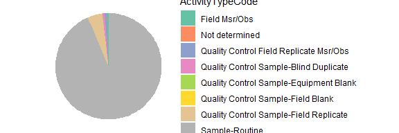

```
#>                                FieldValue Count
#> 8                          Sample-Routine  4396
#> 7  Quality Control Sample-Field Replicate   213
#> 4  Quality Control Sample-Blind Duplicate    35
#> 3 Quality Control Field Replicate Msr/Obs    27
#> 1                           Field Msr/Obs    22
#> 2                          Not determined     2
#> 5  Quality Control Sample-Equipment Blank     2
#> 6      Quality Control Sample-Field Blank     1
```

```r
FilterFieldReview("ActivityTypeCode", TADAProfileClean13)
```

```r
TADAProfileClean14 <- dplyr::filter(TADAProfileClean13, !(ActivityTypeCode %in% c("Quality Control Sample-Field Replicate", "Quality Control Sample-Field Blank", "Quality Control Sample-Lab Duplicate", "Quality Control Sample-Equipment Blank")))
```

We’ve completed our review of the ActivityTypeCode field.

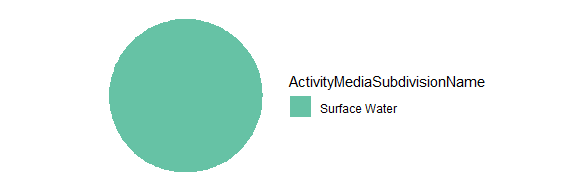

```
#>      FieldValue Count
#> 1 Surface Water  3176
```

```r
FilterFieldReview("ActivityMediaSubdivisionName", TADAProfileClean14)
```

```r
TADAProfileClean15 <- dplyr::filter(TADAProfileClean14, !(ActivityMediaSubdivisionName %in% c("Groundwater", "Bulk deposition")))
```

## Filter data by field, subset by parameter

In this section a TADA user will want to select a parameter, review the unique values associated with that parameter in specific fields, and choose to remove particular values.

To start, review the list of parameters in the dataframe using the **FilterParList** function. (The list is sorted from highest to lowest counts. Only the first few rows are displayed to save space on the page)

```r
FilterParList(TADAProfileClean15)
```

```
#>         FieldValue Count
#> 4   FECAL COLIFORM  3066
#> 5          NITRATE   500
#> 2     ENTEROCOCCUS   360
#> 6         NITROGEN   277
#> 3 ESCHERICHIA COLI   238
#> 1          AMMONIA    41
```

Next, select a parameter. Let’s explore the fields associated with Nitrogen using the **FilterParFields** function:

```r
FilterParFields(TADAProfileClean15, "NITROGEN")
```

```
#>                                         FieldName Count
#> 1         ResultAnalyticalMethod.MethodIdentifier     2
#> 2  ResultAnalyticalMethod.MethodIdentifierContext     3
#> 3                                ActivityTypeCode     2
#> 4                    ActivityMediaSubdivisionName     1
#> 5                             ActivityCommentText    40
#> 6                             HydrologicCondition     7
#> 7                                 HydrologicEvent     6
#> 8         SampleCollectionMethod.MethodIdentifier    14
#> 9  SampleCollectionMethod.MethodIdentifierContext     4
#> 10              SampleCollectionMethod.MethodName    11
#> 11                  SampleCollectionEquipmentName    12
#> 12                           MethodSpeciationName     2
#> 13                           MeasureQualifierCode     4
#> 14                         ResultStatusIdentifier     5
#> 15                            ResultValueTypeName     2
#> 16                          ResultWeightBasisText     2
#> 17                     ResultTemperatureBasisText     1
#> 18                    ResultParticleSizeBasisText     1
#> 19                          DataQuality.BiasValue     1
#> 20                              ResultCommentText     5
#> 21              ResultAnalyticalMethod.MethodName     2
#> 22                                 LaboratoryName     3
#> 23                    ResultLaboratoryCommentText    12
#> 24             DetectionQuantitationLimitTypeName     3
#> 25                     MonitoringLocationTypeName     2
#> 26                         TADA.ActivityMediaName     1
#> 27             TADA.ResultMeasure.MeasureUnitCode     1
#> 28                  TADA.ResultSampleFractionText     3
```

Selecting a parameter generates the list below, which is subset by the selected parameter, of fields and the number of unique values in each field.

Then choose a field from the list. In this example we’ll remove certain values from the HydrologicEvent field.

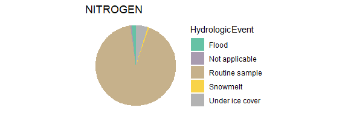

```
#>        FieldValue Count
#> 3  Routine sample   174
#> 5 Under ice cover     9
#> 1           Flood     3
#> 2  Not applicable     1
#> 4        Snowmelt     1
```

```r
FilterParFieldReview("HydrologicEvent", TADAProfileClean15, "NITROGEN")
```

```r
TADAProfileClean16 <- dplyr::filter(TADAProfileClean15, !(TADA.CharacteristicName %in% "NITROGEN" & HydrologicEvent %in% "Storm"))
```

## Transform Characteristic, Speciation, and Unit values to TADA Standards

The **HarmonizeRefTable** function generates a harmonization reference table that is specific to the input dataframe. Users can review how their input data relates to standard TADA values for the following elements:

- TADA.CharacteristicName
- TADA.ResultSampleFractionText
- TADA.MethodSpecificationName
- TADA.ResultMeasure.MeasureUnitCode

The **HarmonizeData** function then compares the input dataframe to the TADA Harmonization Reference Table. The purpose of the function is to make similar data consistent and therefore easier to compare and analyze.

Users can also edit the reference file to meet their needs if desired. The download argument can be used to save the harmonization file to your current working directory when download = TRUE, the default is download = FALSE.

Optional outputs include:

1. the dataframe with Harmonization columns appended,
2. the dataframe with TADA.CharacteristicName, TADA.ResultSampleFractionText, TADA.MethodSpecificationName, and TADA.ResultMeasure.MeasureUnitCode converted to TADA standards or
3. the four fields converted with most Harmonization Reference Table columns appended. Default is transform = TRUE and flag = TRUE.

Here are some examples of how the HarmonizeData function can be used:

1. TADA.ResultSampleFractionText specifies forms of constituents. In some cases, a single *TADA.CharacteristicName** will have both “Total” and “Dissolved” forms specified, which should not be combined. In these cases, each TADA.CharacteristicName and TADA.ResultSampleFractionText combination is given a different identifier. This identifier can be used later on to identify comparable data groups for calculating statistics and creating figures for each combination.
2. Some variables have different names but represent the same constituent (e.g., “Total Kjeldahl nitrogen (Organic N & NH3)” and “Kjeldahl nitrogen”). The HarmonizeData function gives a consistent name (and identifier) to synonyms.

```r
UniqueHarmonizationRef <- HarmonizationRefTable(TADAProfileClean16, download = FALSE)
TADAProfileClean17 <- HarmonizeData(TADAProfileClean16, ref = UniqueHarmonizationRef, transform = TRUE, flag = TRUE)
```

## Characteristic Specific Analyses Below

Address censored data for a single characteristic.

```r
# how to point to a column in R: yourdataset$thecolumnyouwant
# e.g., temp$ResultMeasureValueNitrogenExample <- filter(TADAProfileClean17, CharacteristicName == "NITROGEN")
SingleCharacteristic <- dplyr::filter(TADAProfileClean17, TADA.CharacteristicName == "NITROGEN")

# review the types of censored data you have in your data frame
table(SingleCharacteristic$ResultDetectionConditionText)
```

```
#>
#> Not Detected
#>          100
```

```r
# review number of results that are NA's
sum(is.na(SingleCharacteristic$TADA.ResultMeasureValue))
```

```
#> [1] 0
```

```r
# substitute a value for NA. In this example, 0.02 MG/L is used for NITROGEN
SingleCharacteristic$TADA.ResultMeasureValue <- ifelse(is.na(SingleCharacteristic$TADA.ResultMeasureValue) == TRUE, 0.02, SingleCharacteristic$TADA.ResultMeasureValue)
```

Summarize results for a single characteristic

```r
# add na.rm = TRUE to the function above to strip NA values before the mean computation proceeds
summary(SingleCharacteristic$TADA.ResultMeasureValue, na.rm = TRUE)
```

```
#>    Min. 1st Qu.  Median    Mean 3rd Qu.    Max.
#>  0.0300  0.0365  0.0980  0.3544  0.4020  3.7400
```

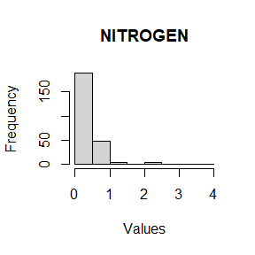

```r
hist(SingleCharacteristic$TADA.ResultMeasureValue, main = unique(SingleCharacteristic$TADA.CharacteristicName), xlab = "Values")
```